# Peeling back the layers: Unraveling the path to #1 NYT Bestselling Status for Fiction Novels

By: Nidhi Chilukuri

# Introduction

The purpose behind this project is to walk you through the data science pipeline, with a focus on New York Times (NYT) Bestsellers and the traditional publishing industry. A lot of people ask the following question: why does it seem like every book is a NYT bestseller Well, according to the NYT itself, the bestseller list is determind solely by sales, during the previous week’s Sunday-to-Saturday sales period.

However, a book's sales are driven by a myriad of underlying factors including popularity, exposure, and marketing. Why are some books purchased more than others? Is it because they are objectively better? Is it because more people have talked about it on social media? Is it because their publishers are devoting more time, money, and energy into marketing?

Those questions lead us to more questions about how the publishing industry treats different books and their authors. As we'll see below, it's not a coincidence that many of the #1 NYT Bestselling authors are white. The traditional publishing industry is characterized by low racial diversity amongst both authors and novels. It's an exclusioanry, cutthroat industry that helps some books see sales numbers in the millions and others disappear off the face of the Earth as if they had never been published in the first place. The industry is dominated by “The Big Five” publishing houses, which control over 80 percent of the trade publishing market and therefore hold the most influence in book manufacturing and selling. To succeed in this brutal industry, connections and wealth are vital.

Together, we're going to dive into the New York Times #1 Bestsellers Lists to analyze the statistics of the books that earn the coveted honor of being placed on there. We already know that books get placed on the list due to sales. But we're going to peel back a few more layers and look into why these books are having such high sales in the first place. We'll be cross-referencing data from the NYT with Goodreads, and trying to see what the hidden factors are.

Let's get to it!

## A quick note before we begin

Goodreads is a book-tracking website owned by Amazon that has a lot of detailed information about millions of books. Sounds great, right? Unfortunately, Goodreads is notoriously difficult to scrape data from. Due to the wealth of book-related information, we will use it for this project. However, it is slow, and because of the way their API is designed, we have to manually search for each novel we want information about. That's a lot of novels! So, there will be two specific sections that will take some time load, labeled below. It's not the most convenient, but it's a necessary evil for the data we need. I recommend letting it run for 3-5 minutes or so to allow it to pull all the data from Goodreads. Maybe stand up and stretch a bit while it does its thing- I promise it's worth the wait!

Let's begin by importing our necessary libraries.

```python
import numpy as np
import pandas as pd
import sklearn
import requests
from bs4 import BeautifulSoup
import matplotlib.pyplot as plt
from selenium import webdriver
import re
from sklearn.model_selection import train_test_split
from sklearn.linear_model import LogisticRegression
from sklearn.metrics import accuracy_score, confusion_matrix, classification_report
```

# Part 1: Data Collection

The first step is to find data that is pertinent to our topic. Since we will be analyzing NYT Bestsellers, the best resource is the NYT itself. The website displays the top 10 books on the NYT Bestsellers list for Young Adult hardcover books on a weekly basis. For example, https://www.nytimes.com/books/best-sellers/2024/01/14/young-adult-hardcover/ displays the list for the week of January 14, 2024. We are interested in the #1 bestsellers for each week, which can also be found more easily here, https://en.wikipedia.org/wiki/Lists_of_The_New_York_Times_number-one_books. Both the NYT and the Wikipedia page contain the same data, and since the Wikipedia page is more consolidated with the specific data we need, we will pull our data from there instead. After obtaining the data from the Wikipedia page, we will extract more data for each book from Goodreads.

First let's scrape the data from Wikipedia (only the fiction books).

```python
years = ["2024", "2023", "2022", "2021"]
titles = []
authors = []
publishers = []
pub_year = []
weeks_on_list = []
i = 0

# Go through the Wikipedia page for each year
for year in years:
    request = requests.get("https://en.wikipedia.org/wiki/List_of_The_New_York_Times_number-one_books_of_" + year)
    soup = BeautifulSoup(request.content, "html.parser")
    tables = soup.find("table")

    for row in tables.find_all('tr'):
        row = [datum.text.strip() for datum in row.find_all('td')][:-1]

        if int(year) <= 2021:
            row = row[1:]

        if row != []:
            titles.append(row[0])
            # No author or publisher provided for that cell
            if len(row) == 1:
                authors.append(np.nan)
                publishers.append(np.nan)
            # No publisher column for that cell
            elif len(row) == 2:
                authors.append(row[1])
                publishers.append(np.nan)
            else:
                authors.append(row[1])
                publishers.append(row[2])
            weeks_on_list.append(1)
            i += 1
            pub_year.append(year)
        elif row == [] and i > 0:
            weeks_on_list[i-1] += 1
```

Next, let's create a Pandas DataFrame with the Wikipedia data we collected.

```python
raw_nyt_data = pd.DataFrame({
    'Title' : titles,
    'Author' : authors,
    'Publisher' : publishers,
    'Year' : pub_year,
    'Weeks on list' : weeks_on_list,
})
```

Let's take a look at the first five rows of our new DataFrame.

```python
raw_nyt_data.head(5)
```

|  | Title | Author | Publisher | Year | Weeks on list |
| --- | --- | --- | --- | --- | --- |
| 0 | Fourth Wing | Rebecca Yarros | Red Tower Books | 2024 | 5 |
| 1 | Random in Death | J. D. Robb | St. Martin's Press | 2024 | 1 |
| 2 | House of Flame and Shadow | Sarah J. Maas | Bloomsbury Publishing | 2024 | 1 |
| 3 | The Women | Kristin Hannah | St. Martin's Press | 2024 | 8 |
| 4 | Just for the Summer | Abby Jimenez | Forever | 2024 | 1 |

# Part 2: Data Processing

The second step is to take the data we've collected and clean it up so we can make some meaning out of it. The Wikipedia page gave us some basic info about the #1 NYT bestsellers over the past four years, but we need more information than the raw data. It's time to turn to Goodreads! We need to use the data from the Wikipedia page and cross-reference it with Goodreads to pull information about the reviews and ratings of each #1 NYT Bestseller. We also need to collect data about Non #1 NYT Bestsellers for future use when we train our model.

We'll clean up the NYT data by merging rows with the same title together into a new DataFrame.

```python
# Create new DataFrame by combining rows with same titles
nyt_data = raw_nyt_data.groupby(['Title']).aggregate({'Author' : 'first', 'Publisher' : 'first', 'Weeks on list': 'sum'}).reset_index()

# Correct a spelling error on the Wikipedia page
nyt_data.loc[nyt_data['Title'] == 'Judgement Prey', 'Title'] = 'Judgment Prey'
```

Now we can view our newly cleaned NYT data.

```python
nyt_data.head(5)
```

|  | Title | Author | Publisher | Weeks on list |
| --- | --- | --- | --- | --- |
| 0 | 21st Birthday | James Patterson and Maxine Paetro | Little, Brown and Company | 1 |
| 1 | A Calamity of Souls | David Baldacci | Grand Central Publishing | 1 |
| 2 | A Court of Silver Flames | Sarah J. Maas | Bloomsbury Publishing | 1 |
| 3 | A Gambling Man | David Baldacci | Grand Central Publishing | 1 |
| 4 | A Slow Fire Burning | Paula Hawkins | Riverhead Books | 1 |

```python
# Authors who had the most #1 NYT Bestselling books
most_popular_authors = nyt_data['Author'].value_counts().head(10).index.tolist()

for author in most_popular_authors:
    print(author)
```

```
John Sandford
David Baldacci
John Grisham
Colleen Hoover
Harlan Coben
Emily Henry
Nora Roberts
Stephen King
James Patterson and Maxine Paetro
J. D. Robb
```

Just as we suspected, the top ten Fiction authors with the most #1 NYT Bestselling books since 2021 are all White. A small observation that sheds a lot of light onto the traditional publishing industry.

This method will allow us to search through a list of books on Goodreads to extract the url for each book, which will come in handy later.

```python
def get_book_urls(url):

    driver = webdriver.Chrome()
    driver.get(url)

    soup = BeautifulSoup(driver.page_source, "html.parser")
    tables = soup.find("table")

    book_urls = []

    for row in tables.find_all('tr'):
        cols = row.findAll('td')
        link = cols[1].find('a').get('href')
        book_urls.append(link)

    return book_urls
```

Now we can use this pre-existing list on Goodreads of #1 NYT Fiction Bestsellers since 2021 to find urls for all the books.

```python
nyt_url = "https://www.goodreads.com/list/show/201219.Number_1_NYT_Fiction_Bestsellers"
nyt_book_urls = get_book_urls(nyt_url)
```

With this method, using the urls collected above, we can extract information from each book on Goodreads. When we call this method, it will take a while. The more books in book_urls, the more novels Goodreads has to process.

```python
def individual_book_info(book_urls):

    driver = webdriver.Chrome()
    info = []

    for url in book_urls:
        driver.get("https://www.goodreads.com" + url)
        soup = BeautifulSoup(driver.page_source, "html.parser")

        b = soup.find("div")

        rating = 0.0
        book_title = ""
        reviews_count = 0
        ratings_count = 0

        # Get the rating from Goodreads
        for row in b.find_all('span', attrs={'aria-hidden': 'true'}):
            aria_label = row.find('span')
            if aria_label:
                aria_label2 = aria_label.get('aria-label')
                rating = float(re.search(r'[\d,.]+', aria_label2[7:11]).group())

        # Get the title from Goodreads
        for row in b.find_all(lambda tag: tag.name == "div" and tag.get('class') == ["BookPageTitleSection__title"]):
            aria_label = row.find('h1')
            aria_label2 = aria_label.get('aria-label')
            book_title = aria_label.get_text(strip=True)

        # Get the number of ratings from Goodreads
        for row in b.find_all('span', attrs={'aria-hidden': 'true', 'data-testid': 'ratingsCount'}):
            ratings_text = row.get_text(strip=True)
            ratings_number = re.search(r'[\d,]+', ratings_text).group()
            ratings_count = int(ratings_number.replace(',', ''))

        # Get the number of reviews from Goodreads
        for row in b.find_all('span', attrs={'aria-hidden': 'true', 'data-testid': 'reviewsCount'}):
            reviews_text = row.get_text(strip=True)
            reviews_number = re.search(r'[\d,]+', reviews_text).group()
            reviews_count = int(reviews_number.replace(',', ''))

        info.append([book_title, rating, ratings_count, reviews_count])

    return info
```

Let's get additional book information for the NYT data.

```python
nyt_book_info = individual_book_info(nyt_book_urls)
```

Let's also use this pre-existing list on Goodreads of popular books of the 2020s to find urls for all the Non NYT books.

```python
non_nyt_url = "https://www.goodreads.com/list/show/143500"
non_nyt_book_urls = get_book_urls(non_nyt_url)
```

We can now et book inforomation for the Non NYT data too.

```python
non_nyt_book_info = individual_book_info(non_nyt_book_urls)
```

Now we can add our new information to the nyt_data DataFrame we created earlier.

```python
nyt_data['Rating'] = 0.0
nyt_data['Total Ratings'] = 0
nyt_data['Total Reviews'] = 0
index = 0

for info in nyt_book_info:

    # Onl process valid books
    if info[0] != '' and info[1] != 0.0 and info[2] != 0 and info[3] != 0:

        # Special case (discrepancy in data scraping that needs to be manually corrected)
        if info[0] == 'A \u200bCourt of Silver Flames':
            index = nyt_data[nyt_data["Title"] == 'A Court of Silver Flames'].index[0]
        else:
            index = nyt_data[nyt_data["Title"] == info[0]].index[0]
        nyt_data.at[index, 'Rating'] = info[1]
        nyt_data.at[index, 'Total Ratings'] = info[2]
        nyt_data.at[index, 'Total Reviews'] = info[3]
```

Let's view the updated nyt_data DataFrame with ratings for each book.

```python
nyt_data.head(5)
```

|  | Title | Author | Publisher | Weeks on list | Rating | Total Ratings | Total Reviews |
| --- | --- | --- | --- | --- | --- | --- | --- |
| 0 | 21st Birthday | James Patterson and Maxine Paetro | Little, Brown and Company | 1 | 4.17 | 35951 | 1906 |
| 1 | A Calamity of Souls | David Baldacci | Grand Central Publishing | 1 | 4.58 | 8274 | 709 |
| 2 | A Court of Silver Flames | Sarah J. Maas | Bloomsbury Publishing | 1 | 4.47 | 1156645 | 103733 |
| 3 | A Gambling Man | David Baldacci | Grand Central Publishing | 1 | 4.14 | 39422 | 2094 |
| 4 | A Slow Fire Burning | Paula Hawkins | Riverhead Books | 1 | 3.50 | 156414 | 12612 |

We have to create a Non NYT DataFrame and add the information from Goodreads.

```python
non_nyt_data = pd.DataFrame(non_nyt_book_info, columns=['Title', 'Rating', 'Total Ratings', 'Total Reviews'])
non_nyt_data['Rating'] = non_nyt_data['Rating'].astype(float)
```

Let's take a look at our Non NYT DataFrame

```python
non_nyt_data.head(5)
```

|  | Title | Rating | Total Ratings | Total Reviews |
| --- | --- | --- | --- | --- |
| 0 | The Invisible Life of Addie LaRue | 4.19 | 1088990 | 140198 |
| 1 | The House in the Cerulean Sea | 4.40 | 642958 | 102340 |
| 2 | Project Hail Mary | 4.51 | 581488 | 72494 |
| 3 | The Midnight Library | 4.00 | 1803215 | 186443 |
| 4 | I'm Glad My Mom Died | 4.46 | 1011776 | 106628 |

# Part 3: Exploratory Data Analysis

Now that we have more information about the books, we need to visualize our data so we can understand the patterns we have. We're interested in the popularity of books, so we need to look at trends among the average rating, total ratings, and total reviews of books on Goodreads along with how they relate to the book's status as an NYT Bestseller. Let's make some graphs and analyze the data.

First we'll make a scatterplot of total ratings vs total reviews.

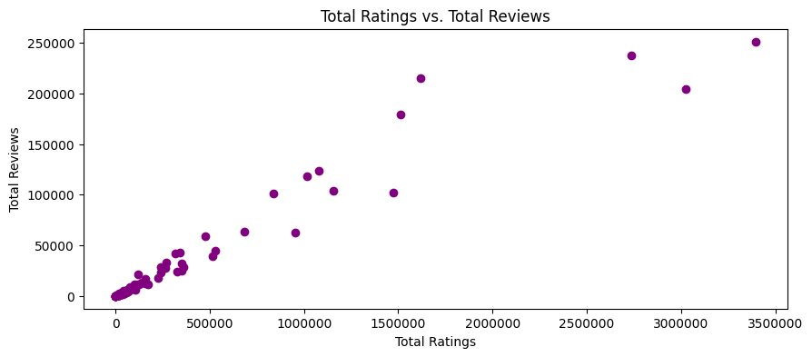

```python
fig, ax = plt.subplots(figsize=(10, 4))

ax.scatter(nyt_data['Total Ratings'], nyt_data['Total Reviews'], color='purple')
ax.set_xlabel('Total Ratings')
ax.set_ylabel('Total Reviews')
ax.set_title('Total Ratings vs. Total Reviews')

ax.ticklabel_format(style='plain', axis='x')
plt.show()
```

From this graph, we can see a gradual increasing trend between total ratings and total reviews. Most books tend to be on the lower end for both.

Next we'll make a scatterplot of total ratings vs average rating of each book.

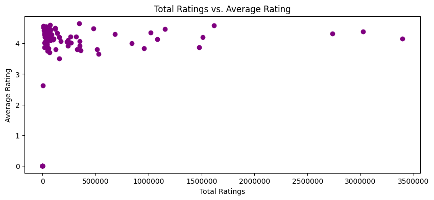

```python
fig, ax = plt.subplots(figsize=(10, 4))

ax.scatter(nyt_data['Total Ratings'], nyt_data['Rating'], color='purple')
ax.set_xlabel('Total Ratings')
ax.set_ylabel('Average Rating')
ax.set_title('Total Ratings vs. Average Rating')
ax.ticklabel_format(style='plain', axis='x')

plt.show()
```

From this graph, we can see that the average rating tends to be around 4 across the range of total ratings.

Finally, we'll make a scatterplot of total reviews vs average rating of each book.

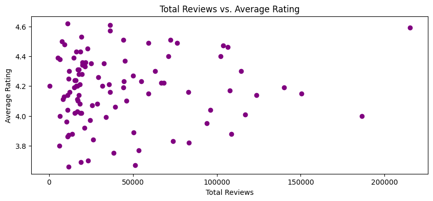

```python
fig, ax = plt.subplots(figsize=(10, 4))

ax.scatter(non_nyt_data['Total Reviews'], non_nyt_data['Rating'], color='purple')
ax.set_xlabel('Total Reviews')
ax.set_ylabel('Average Rating')
ax.set_title('Total Reviews vs. Average Rating')
ax.ticklabel_format(style='plain', axis='x')

plt.show()
```

From this graph, we can see that the average rating tends to be around 4 across the range of total reviews as well.

All together, we can see that total reviews and total ratings seem to have more of a relationship than average rating, which appears to be around 4 across the board.

# Part 4: Hypothesis Testing and Machine Learning

Now that we've visualized our data and seen how our three variables of interest, average rating, total ratings, and total reviews interact with each other, we need to take everything we've done and see if we can create a model that will predict whether a book is a #1 NYT bestseller based on its reviews and ratings on Goodreads. We will focus on the total ratings and total reviews, and leave average rating out of our model after seeing the graphs above.

We have two classes, Yes and No for whether a book is a #1 NYT bestseller. Since this is a classification problem, we won't be able to use Linear Regression. Instead, let's use a Logistic Regression model to classify books into two categories: 0 for No and 1 for Yes. Let's train our model and see how it performs. But first, we need to combine the two DataFrames we have (Non #1 NYT bestsellers and #1 NYT bestsellers) so that we can use them together to split into our training and testing sets.

First we'll label our data.

```python
# Label the data of non NYT bestsellers
non_nyt_data['NYT Bestseller'] = 0

# Label the data of NYT bestsellers
nyt_data['NYT Bestseller'] = 1
```

Next we can filter our Non NYT data so we only keep books in the non_nyt_data that aren't already in the nyt_data to account for overlap errors in the Goodreads lists.

```python
filtered_non_nyt_data = non_nyt_data[~non_nyt_data['Title'].isin(nyt_data['Title'])]
```

Now we can create a comprehensive dataset by combining the NYT DataFrame from above with the DataFrame of Non NYT #1 bestsellers.

```python
combined_data = pd.concat([nyt_data, filtered_non_nyt_data], ignore_index=True)
```

Let's view the combined DataFrame!

```python
combined_data.head(5)
```

|  | Title | Author | Publisher | Weeks on list | Rating | Total Ratings | Total Reviews | NYT Bestseller |
| --- | --- | --- | --- | --- | --- | --- | --- | --- |
| 0 | 21st Birthday | James Patterson and Maxine Paetro | Little, Brown and Company | 1.0 | 4.17 | 35951 | 1906 | 1 |
| 1 | A Calamity of Souls | David Baldacci | Grand Central Publishing | 1.0 | 4.58 | 8274 | 709 | 1 |
| 2 | A Court of Silver Flames | Sarah J. Maas | Bloomsbury Publishing | 1.0 | 4.47 | 1156645 | 103733 | 1 |
| 3 | A Gambling Man | David Baldacci | Grand Central Publishing | 1.0 | 4.14 | 39422 | 2094 | 1 |
| 4 | A Slow Fire Burning | Paula Hawkins | Riverhead Books | 1.0 | 3.50 | 156414 | 12612 | 1 |

Now we can split the combined data into training and testing sets.

```python
X = combined_data[['Total Ratings', 'Total Reviews']]
y = combined_data['NYT Bestseller']
X_train, X_test, y_train, y_test = train_test_split(X, y, test_size=0.2)
```

Let's train the logistic regression model and make predictions using our model.

```python
log_reg_model = LogisticRegression()
log_reg_model.fit(X_train, y_train)

y_pred = log_reg_model.predict(X_test)
```

With our predictions, we can evaluate the model using our confusion matrix and classification report.

```python
conf_matrix = confusion_matrix(y_test, y_pred)
class_report = classification_report(y_test, y_pred, output_dict=True)
class_report_df = pd.DataFrame(class_report).transpose()
```

Let's take a closer look at our classification report to see our precision and recall values.

```python
class_report_df
```

|  | precision | recall | f1-score | support |
| --- | --- | --- | --- | --- |
| 0 | 0.812500 | 0.764706 | 0.787879 | 17.000000 |
| 1 | 0.818182 | 0.857143 | 0.837209 | 21.000000 |
| accuracy | 0.815789 | 0.815789 | 0.815789 | 0.815789 |
| macro avg | 0.815341 | 0.810924 | 0.812544 | 38.000000 |
| weighted avg | 0.815640 | 0.815789 | 0.815140 | 38.000000 |

# Part 5: Interpretation

From our classification report, we can see that our precision and recall show that our model is fairly average at predicting whether a book will be a #1 NYT Bestseller based on its total ratings and total reviews on Goodreads. We wanted to understand how a book's popularity on a popular book-tracking site (Goodreads) affected its ability to become a #1 NYT Bestseller.

We learned that a book's popularity is just one factor that goes into whether it becomes a #1 NYT Bestseller. While using a book's total ratings and total reviews can be a useful indicator of its popularity and exposure, it doesn't necessarily indicate whether it will become a #1 NYT Bestseller. However, it does play a role, just as we suspected in the beginning about how popularity imapcts sales, and interactions on Goodreads can impact how well a book does. A book with a low number of reviews and ratings may not do as well as a book with more ratings and reviews. Exposure does impact how well a book does.

This was a baseline analysis of Goodreads and NYT Bestseller data. It's only the starting point, and there's so much more to explore! For the future, we could examine more years and other factors aside from average rating, total ratings, and total reviews on Goodreads. There's many potential factors that impact how well a book sells, and we could use those to improve our model and better understand how the NYT Bestsellers List operates.

While scraping data from Goodreads can be a challenge, we can also learn a lot about not just book statistics but also about the traditional publishing industry as a whole. Until we work to peel apart the layers that make up a successful book, we won't be able to dismantle the exclusionary practices of the industry. There's a lot of work to be done, and it starts here!

For more information about the traditional publishing industry and the NYT Bestseller List, I recommend reading the following articles:

Research & Policy: Stories ‘Still’ Matter: Rethinking the Role of Diverse Children’s Literature Today: http://www.jstor.org/stable/44809887

Diversity, Media and Racial Capitalism: A Case Study on Publishing: https://doi.org/10.1080/01419870.2022.2032250

Diversity and Inclusion in Publishing: What Do We Know?: https://doi.org/10.1007/s12109-021-09805-w

Publishing Industry Diversity in the U.S. - Statistics & Facts: https://www.statista.com/topics/7634/diversity-in-the-us-publishing-industry/#dossierKeyfigures

What Are the ‘Big Five’ Publishing Houses?: https://bookscouter.com/blog/big-five-publishing-houses/

A Lot of Data and a Little Singing: How The Times’s Best-Seller List Comes Together: https://www.nytimes.com/2020/09/23/insider/best-seller-list-process.html

The New York Times Bestseller Lists Explained: https://www.novlr.org/the-reading-room/the-new-york-times-bestseller-lists-explained

Thank you for joining me, and keep reading (not just #1 NYT Bestsellers)!